# Introduction to Data Science Using R

Korbel Skills Workshop

Instructor – Jason Renn

November 26, 2017

# Required Software

Welcome to the first Korbel Skills Workshop[^1]. These materials are available online at the following url:

> https://du-data-science.github.io/korbel-skills-workshops/ (http://bit.ly/2hI2bYk)

You will need to install the following software for this workshop. Please install both (in order) in the next several minutes as we begin with a brief introduction of Data Science and the R statistical programming language.[^2]

- [R Statistical Programming Language](https://cran.r-project.org/)
- [RStudio IDE](https://www.rstudio.com/products/rstudio/download/#download)

## What is Data Science?

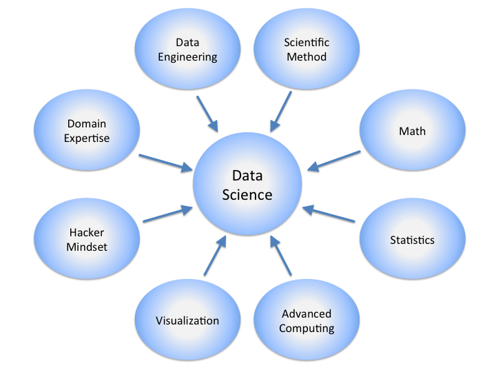

Beyond its status as a buzzword[^3], data science is simply a combination of a number of quantitatively-oriented skills, including statistics, mathematics, and computer science. There are many other terms and specific skills, but these are the core.

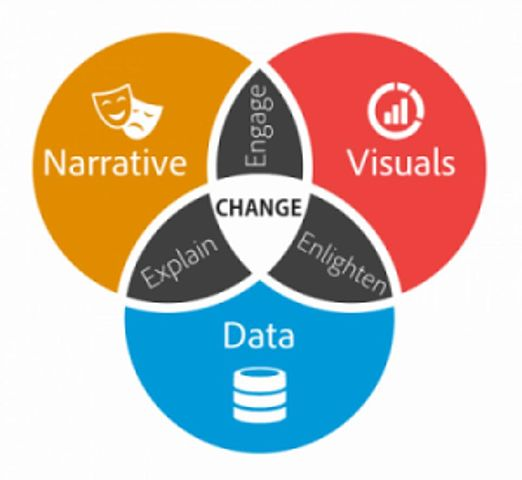

I would add that on top of the computer/quantitative skills, you will also have to learn how to write about and discuss data science techniques if you plan on using them in your career. Even for those of you that do not plan on persuing research, you will find yourself in a professional setting where you will have to engage with data. Why learn these data science skills? They should complement your knowledge about the content (domain expertise) and rhetorical skills *to help make you heard*.

These workshops will only serve as an introduction to these tools, primarily the software. If you want more training in these skills, know that it will require work. We will discuss more advanced uses of these tools and additional training at the end of the workshop.

## Why `R`?

[figure not shown]

`R` is a computer programming language. It is open-source, popular, and strikes a balance between having more flexibility than many other software packages (e.g. Stata, SPSS) and being a little easier to use (e.g. Python, SAS, S). If you encounter data science in your careers, it will probably be in `R`.[^4]

Consider the example of the 2012 Presidential Campaign.[^5] The Obama campaign used data scientists, to collect data and create statistical models to help register voters and their craft outreach strategy. [Rayid Ghani](http://www.rayidghani.com/), a fellow at the University of Chicago and the Chief Scientist for the 2012 Obama for America campaign, led the effort. One of tools that he and his team used? `R`.

[figure not shown]

Will `R` always be around? Probably not. But it will prepare you to learn new languages as well. If you go further with data science, you will probably have to learn some other software. This is a mindset as much as it is formal training.

# Exploring RStudio

RStudio is an Integrated Development Environment (IDE) that makes R much easier to use than in days past. There is a lot of functionality built into RStudio, including dynamic documents, version control, and linkages to cloud-based resources. We won’t cover those today – just the basics. For now, open up RStudio to make sure that the install worked.

## The Interface

You should see something that looks like the image below:

[figure not shown]

By default there is space for four panels, though the top-left panel may be minimized the first time that you open RStudio.[^6] Don’t worry. We’ll cover that in a moment.

### Console

The first place that you should look is the console. This is where you enter code and commands into R for your computer to process. In the old days, we’d have to open up a terminal/command prompt.

Try to enter the following code into the **Console** panel to make sure that RStudio can correctly locate `R`. If successful, you the console should print out a friendly little message.

```r
print("hello world")
```

### Environment

In the top-right corner is a panel that has multiple tabs. Select the **Environment** tab if it isn’t already selected. Note that it should currently say “Environment is empty.”

One of the virtures of R is that it can load several objects into memory. Other software (Stata in particular) only loads one. While this helps keep the enviroment clean, it can make data management tasks pretty difficult. Let’s make a few objects in R and save them. Make sure to pay attention to the **Environment** tab to see how it changes with the following commands. Type or copy/paste the following lines into the **Console**.

```r
# This is a comment.
# Any line in R that begins with a "#" will not execute. For example:
# print("hello")
# Use comments to document code. I will use it provide additional explanation for code-related topics.
# Don't worry about typing of copying commented lines. Do read them.

# To assign a value, use the "<-". You can also use an "=" but that is typically reserved. We'll see why later.
# You can lie about your age if you want.
yourAge <- 28
favoriteColor <- "blue"
x = 1
y = 3
```

What happened to the environment? You can now call any of the variables that you just created by referring to the by name. Try thte following:

```r
x
y
x+y
```

Note that R is case sensitive. Typing the following will give you an error.

```r
yourage
favoritecolor
```

You also can’t save a variable with a space in the name – at least you shouldn’t.

```r
# This won't work
your age <- 28
```

### File Explorer

In the bottom-right, you’ll see the **Files** panel. You can access files saved on your computer here and if it is a file that R can load as a dataset, then you’ll also get a prompt with options. You could easily never touch the **Files** panel, instead using the **Console** or options within the “File ->” menu to access things, but it can be useful. There are usually three or four ways to do something in ‘R’. Do what works for you.

### Scripts, Markdown, Datasets

The final panel contains text files that you can edit and will also display datasets. Most often, this space will have either a `.R` (script) or `.Rmd` (RMarkdown) file where you can save commands and output. Similar to a Stata `.do` file, this allows you to keep a record of everything you’ve done in case you have to redo something. Unlike the console output, you can easily save these files. The console output will get cleared from time to time. We won’t create a script or markdown file today, but they are useful.

## Installing and Requiring Packages

One of the best aspects of `R` is that people continue to develop additional features and expand the functionality. Any user can download and attach these software packages to their own installation of `R`. Since this is all open-source, there aren’t any warranties or support, so the challenge with these packages is keeping them up-to-date and reading through some rather obtuse documentation.

We’re going to install a few packages right now that will allow us to load data into ‘R’ from several file formats.

```r
# During the installation process, R may ask you to create a personal library or restart R. This should be fine.
# You can install one package at a time
install.packages("haven")

# Or multiple
install.packages("readxl", "foreign")
```

With these packages installed, you can now use commands that are not part of “base `R`.